# ACE 427 Commodity Price Analysis and Forecasting

# September 11, 2015 WASDE Breakdown, Corn

- U.S. corn usage for 2015/16 is lowered 20 million bushels, but usage is expected to be record high and just above the level projected for 2014/15.
- Feed and residual use for 2015/16 is expected 25 million bushels lower with the smaller crop.
- FSI use is projected 5 million bushels higher on an increase in expected use for sweeteners consistent with this month’s upward revision to that usage category for 2014/15.
- Despite higher projected global import demand, projected corn exports for 2015/16 are unchanged with tighter supplies.
- U.S. ending stocks for 2015/16 are projected 121 million bushels lower and 140 million bushels below this month’s lowered 2014/15 carryout projection.
- The 2015/16 season-average corn price received by producers is projected 10 cents higher on both ends to $3.45 to $4.05 per bushel.

Source: [September 2015 WASDE](http://www.usda.gov/oce/commodity/wasde/)

| Corn | Final_2013.2014 | Est_2014.2015 | Projected_2015.2016 | Projected_2015.2016.1 |
| --- | --- | --- | --- | --- |
| **Million Acres** |  |  | Aug | Sep |
| Area Planted | 95.4 | 90.6 | 88.9 | 88.9 |
| Area Harvested | 87.5 | 83.1 | 81.1 | 81.1 |
| **Bushels** |  |  |  |  |
| Yield per Harvested Acre | 158.1 | 171 | 168.8 | 167.5 |
| **Million Bushels** |  |  |  |  |
| Beginning Stocks | 821 | 1232 | 1772 | 1732 |
| Production | 13829 | 14216 | 13686 | 13585 |
| Imports | 36 | 30 | 30 | 30 |
| **Supply, Total** | **14686** | **15477** | **15488** | **15347** |
| Feed and Residual | 5041 | 5300 | 5300 | 5275 |
| Food, Seed & Industrial | 6493 | 6570 | 6625 | 6630 |
| Ethanol & by-products | 5124 | 5205 | 5250 | 5250 |
| Domestic, Total | 11534 | 11870 | 11925 | 11905 |
| Exports | 1920 | 1875 | 1850 | 1850 |
| **Use, Total** | **13454** | **13745** | **13775** | **13755** |
| Ending Stocks | 1232 | 1732 | 1713 | 1592 |
| **Avg. Farm Price ($/bu)** | **4.46** | **3.68** | **3.35 - 3.95** | **3.45 - 4.05** |

# September 11, 2015 WASDE Breakdown, Soybeans

- Soybean production is forecast at 3,935 million bushels, up 19 million due to a higher yield forecast.
- Soybean crush is raised 10 million bushels to 1,870 million on increased domestic disappearance of soybean meal, which is raised in line with an increase for 2014/15.
- With lower beginning stocks and higher use, soybean ending stocks are projected at 450 million bushels, down 20 million.
- Changes for 2014/15 include higher exports and crush, resulting in reduced ending stocks.
- Exports are increased 10 million to a record 1,835 million bushels based on reported trade through July and indications from August export inspections.
- Crush is increased 25 million bushels to 1,870 million on increased soybean meal domestic disappearance and exports. Ending stocks are projected at 210 million bushels, down 30 million.
- The 2015/16 U.S. season-average soybean price is projected at $8.40 to $9.90 per bushel, unchanged from last month. Soybean meal prices are also unchanged at $310 to $350 per short ton.
- Soybean oil prices are projected at 27.5 to 30.5 cents per pound, down 2 cents on both ends of the range.

Source: [September 2015 WASDE](http://www.usda.gov/oce/commodity/wasde/)

| Soybean | Final_2013.2014 | Est_2014.2015 | Projected_2015.2016 | Projected_2015.2016.1 |
| --- | --- | --- | --- | --- |
|  |  |  | Million Acres |  |
| Area Planted | 76.8 | 83.7 | 84.3 | 84.3 |
| Area Harvested | 76.3 | 83.1 | 83.5 | 83.5 |
| Filler |  |  | Bushels |  |
| Yield per Harvested Acre | 44 | 47.8 | 46.9 | 47.1 |
|  |  |  | Million Bushels |  |
| Beginning Stocks | 141 | 92 | 240 | 210 |
| Production | 3358 | 3969 | 3916 | 3935 |
| Imports | 72 | 33 | 30 | 30 |
| **Supply, Total** | **3570** | **4094** | **4186** | **4175** |
| Crushings | 1734 | 1870 | 1860 | 1870 |
| Exports | 1638 | 1835 | 1725 | 1725 |
| Seed | 97 | 98 | 92 | 92 |
| Residual | 9 | 81 | 40 | 38 |
| **Use, Total** | **3478** | **3884** | **3717** | **3725** |
| Ending Stocks | 92 | 210 | 470 | 450 |
| **Avg. Farm Price ($/bu)** | **13** | **10.06** | **8.40 - 9.90** | **8.40 - 9.90** |

# Lecture for Chapter 5

# Introduction

- The preceding chapters have served as a background about agricultural markets, and important informational events that drive commodity prices.
- Going forward, we will focus our energy on the more data and technical questions of actually forecasting elements of the balance sheet - and later, short term price changes using time-series econometric techniques.
- In the remainder of this chapter, the discussion and figures are all for corn.

# Forecasting Production

- Our first task in forecasting a balance sheet will be to get a good estimate of production for the marketing year.
- As we noted before, `Production = Acreage X Yield`.
- To begin, we will discuss the fundamentals of estimating acreage.

# Estimating Acreage

- Like many other agricultural variables we would like to forecast, our methodology for forecasting acreage depends on the time of year we are making the forecast.
- Prior to planting season, we can rely on recent trends in acreage from previous years, plus relative profitability of planting competing crops as measured by relative futures prices.

# Historical acres planted and harvested can be found from USDA NASS.

## Steps to download historical acreage data:

> 1. Go to http://www.nass.usda.gov/Data_and_Statistics/index.asp
> 2. Click *Crops and Plants* in the menu on the left of the screen
> 3. In the query, choose *Crops* and then *Field Crops*
> 4. Hold down the control key and choose corn
> 5. Click the check boxes for *ACRES PLANTED*, *ACRES HARVESTED*, *Price Recieved*, and *Yield* and click the *CONTINUE* button
> 6. You will see a small table; in the bottom right-right hand corner there is a *more…* link. Click it
> 7. Choose *Save::Spreadsheet*, and a Microsoft Excel file will download.

# Historical Acreage for Corn

[figure not shown]

# Historical Acreage for Corn

The following is a graph of historical corn *Planted Acres* along with the ratio of *Average Prices Received by Farmers* for corn and soybeans.

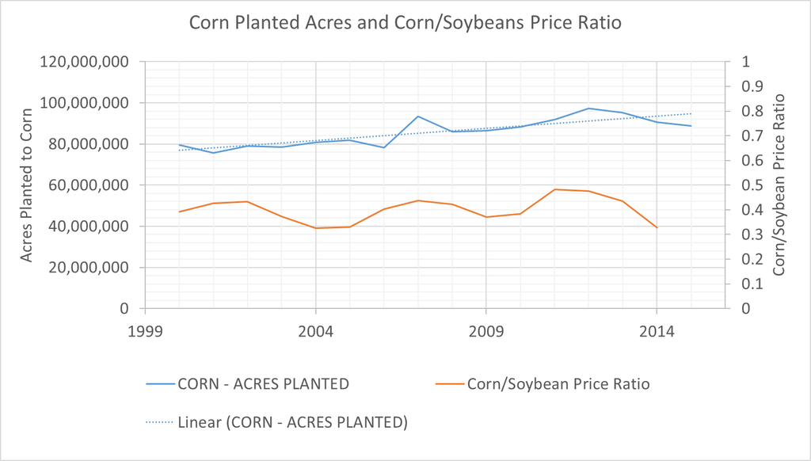

Based on the information in Figure 2, one might predict a decline in corn planted acres in the spring of 2015. Although, at the time of planting, the November soybean and December corn futures prices will be the appropriate prices to use for this analysis, because they represent expected profit.

# Relative Prices of Crops Competing for Acres

- For example, the following graph shows the December 2016 and November 2016 corn and soybean futures prices respectively for 8/1/2015 to 9/10/2015.
- The ratio is not graphed here, but since the price of corn is rising relative to the price of soybeans, the relative profitability has drifted toward corn over this time frame.
- Forecasts of corn and soybean acreage for Spring 2016 should take this into account.

[figure not shown]

## Forecasting Harvested Acres

After forecasting *Planted Acres* one still needs to provide a forecast for *Harvested Acres*. Figure 4 shows historical trends in *Harvested Acres* relative to *Planted Acres*. The difference between these two variables is provided in grey with units along the right axis for convenience.

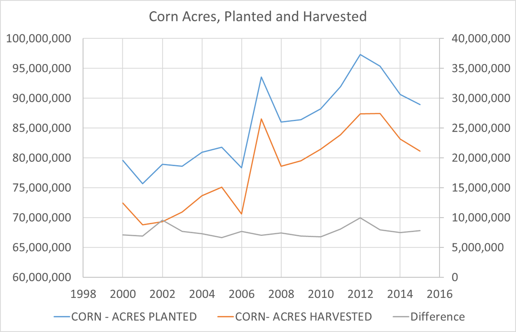

Harvested acres tends to be a fairly stable number, averaging 7.6 million acres between 2000 and 2014. Although, years when this variable deviates most from trend corresponds to years of exceptionally poor production. See 2012 and 2002 as examples. These years marginal reductions in production are explained by reduced yield and abandoned acres, so forecasting the harvested acres number accurately becomes very important to accurately forecasting production in shortfall years.

# Forecasting Yield

Just like in forecasting acreage, we have different procedures for forecasting yield prior to planting. Before the summer growing season gets underway, trend yield. The trouble is, where to start?

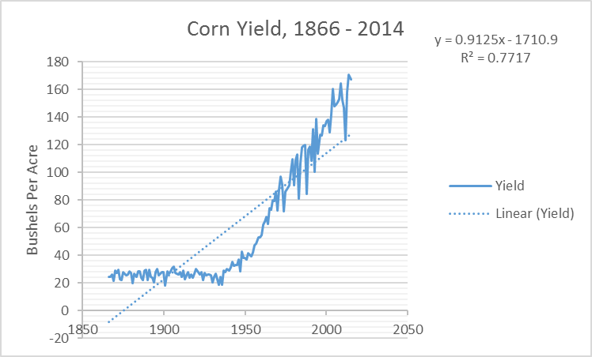

- USDA has records on yield that go back to 1866.
- While one often thinks more information is better when forecasting, the old yield estimates are no longer useful for forecasting current yield. Technological progress caused yields to take of in the 1950’s and they have been climbing ever since.
- In the forecasting world, this is called *structural change* or a *structural break*.
- If *structural change* has occurred, the world looks so different now than it did before the structural change that data from before the break just is not useful for forecasting going forward.

# Forecasting Yield

It turns out that if you estimate a trend-line beginning with 1952, with 1980, or with pretty much any date in between, you will get an estimate that is roughly similar.

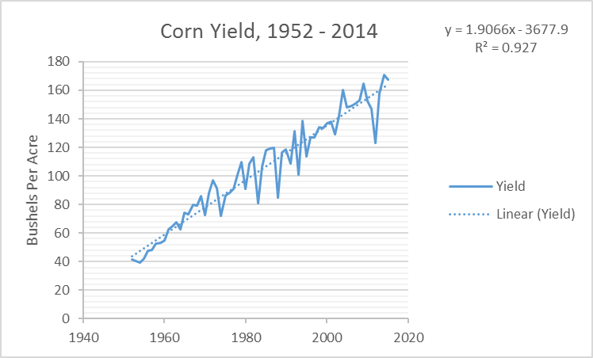

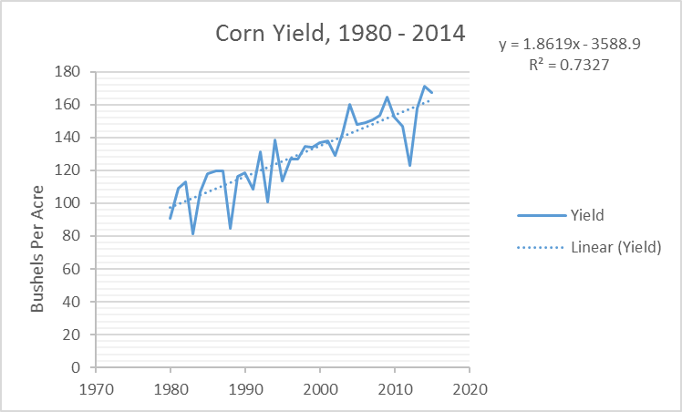

For example, using the trend-line beginning with 1952 to forecast yield we come up with $Yield^{2015} = 1.9066*2015 - 3677.9 = 163.899$. While, using the trend-line beginning with 1980 to forecast yield we come up with $Yield^{2015} = 1.8619*2015 - 3588.9 = 162.8285$.

# Forecasting Yield during the Growing Season

- The USDA has an extensive methodology to estimate yield during the growing season.
- Prior to August, they conduct the **Agricultural Yield Survey** (AYS) which surveys a large number of farmers and ask them to estimate yield.
- Beginning in August, the USDA conducts what it calls the **Objective Yield Survey**.
- They take samples from a relatively large number of fields and estimates yield in those fields based on various factors such as counts of plants, ears, and pods (for soybeans) [@good2011yield].

# Forecasting Yield during the Growing Season

- The job of the analyst who is not employed by the USDA is most likely to anticipate the yield forecast of the USDA, or possibly to make a forecast that does better than the USDA.
- Then the analyst can capitalize on superior private information by making a well advised business decision or earning speculative profits.

# Forecasting Yield during the Growing Season

- An independent analyst will not have the same level of resources the USDA deploys to provide monthly yield estimates; he or she will have to rely on historical data and a basic understanding of how weather affects crop yields.
- Figure 8 below plots each year’s deviation from trend yield since 1980.
- The first plot is in levels (i.e., $Yield_t - Trend Yield_t$); whereas the second plot is in percent terms (i.e., $\ln{Yield_t} - \ln{Trend Yield_t}$.
- Notice that the shape looks roughly the same, but the 2012 drought looks worse expressed in level deviations than the short crops of 1983, 1988, and 1993.
- This is because yield is trending higher. In percentage terms we see that the 2012 drought was equally as bad as 1983 and not quite as bad as 1988.

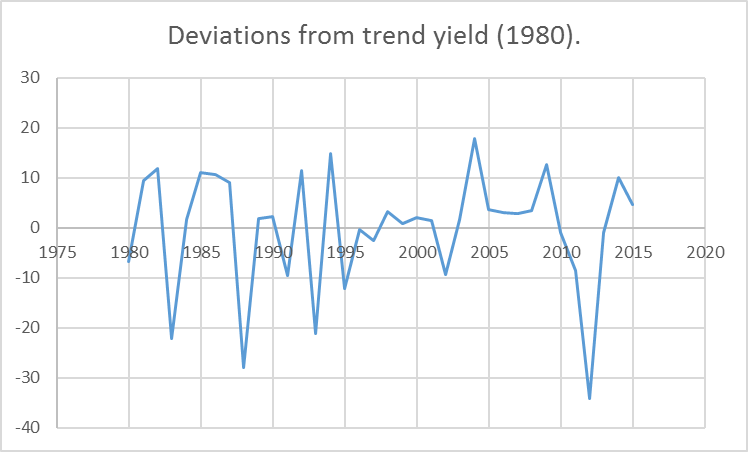

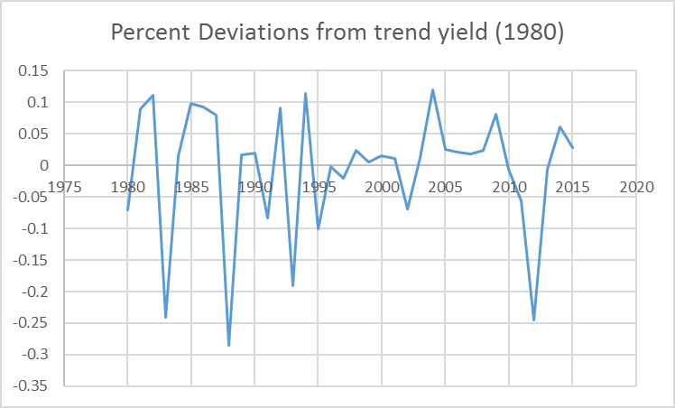

# Forecasting Yield during the Growing Season

Short of an advanced agronomic model that can take into account planting date, precipitation, [growing degree days](https://en.wikipedia.org/wiki/Growing_degree-day), or ability to estimate yield from remote sensing technology [@unganai1998drought], we will have to resort to the *similar year approach*.

# Forecasting Yield during the Growing Season

Analysts often estimate deviations from trend yield by finding year similar to the current one in terms of weather. The assumption is that if the weather patterns were similar then the percent deviation from trend yield should be similar as well. Note here that percent deviation is preferable so you do not need to adjust for the increasing trend in yield as you look backward to a similar year.

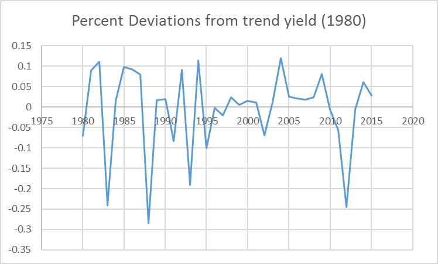

# Forecasting Yield during the Growing Season

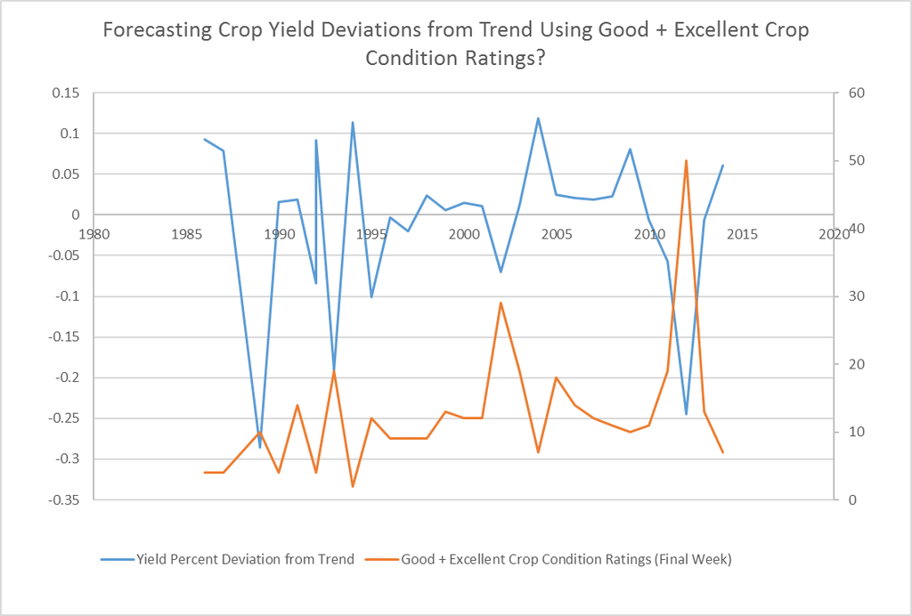

# Forecasting Production

Once you have an estimate for acreage and yield, you can multiply them to give you an estimate of production for your balance sheet forecast.

# Conclusion

In this chapter we discussed the basics of forecasting production. First we discussed forecasting acreage, then we moved on to forecasting yield both before and during the growing season. We discovered that estimating yield percent deviations from trend better than the USDA is extremely difficult. Even anticipating whether the yield forecast will go up or down is not an easy task. The *similar year method* has its limitations when used to find similar years in terms of weather or crop conditions ratings.

# Exercises

1. Use NASS data for soybeans for forecast production in a similar mannar we we did in class for corn.